# ゲームハード週販レポート (2025.10.12)

国内ゲームハード週販レポート (2025-10-12)

- ハードウェアの販売データはファミ通の調査結果を基にしています。
- 一部のデータは処理上の都合により、週次値に調整しています。
- 過去の週販レポート

## 直近4週間のハード売り上げ／累計推移

嵐の前の静けさ、目立った変化のない週です。 PS5も通常の水準よりも若干高めですが元に戻りSwitchを下回っています。

来週は大きな動きが予想されます。

- Nintendo Switch2 Pokemon ZA同梱版
- PS5 AUTUMN SALE (10/17~10/23)

どこまで売り上げが伸びるか注目です

| 集計日 | ハード | 販売台数 | 累計台数 |
| --- | --- | --- | --- |
| 2025-09-21 | Nintendo Switch2 | 40,711 | 2,065,472 |
|  | Nintendo Switch | 16,612 | 36,005,334 |
|  | PlayStation5 | 8,384 | 7,040,024 |
|  | Xbox Series X\|S | 395 | 684,074 |
|  | PlayStation4 | 18 | 9,490,813 |
| 2025-09-28 | Nintendo Switch2 | 44,150 | 2,109,622 |
|  | Nintendo Switch | 23,110 | 36,028,444 |
|  | PlayStation5 | 16,911 | 7,056,935 |
|  | Xbox Series X\|S | 441 | 684,515 |
|  | PlayStation4 | 21 | 9,490,834 |
| 2025-10-05 | Nintendo Switch2 | 44,439 | 2,154,061 |
|  | PlayStation5 | 27,344 | 7,084,279 |
|  | Nintendo Switch | 24,109 | 36,052,553 |
|  | Xbox Series X\|S | 837 | 685,352 |
|  | PlayStation4 | 19 | 9,490,853 |
| 2025-10-12 | Nintendo Switch2 | 46,842 | 2,200,903 |
|  | Nintendo Switch | 23,149 | 36,075,702 |
|  | PlayStation5 | 14,800 | 7,099,079 |
|  | Xbox Series X\|S | 237 | 685,589 |
|  | PlayStation4 | 17 | 9,490,870 |

## 2025年の週販推移

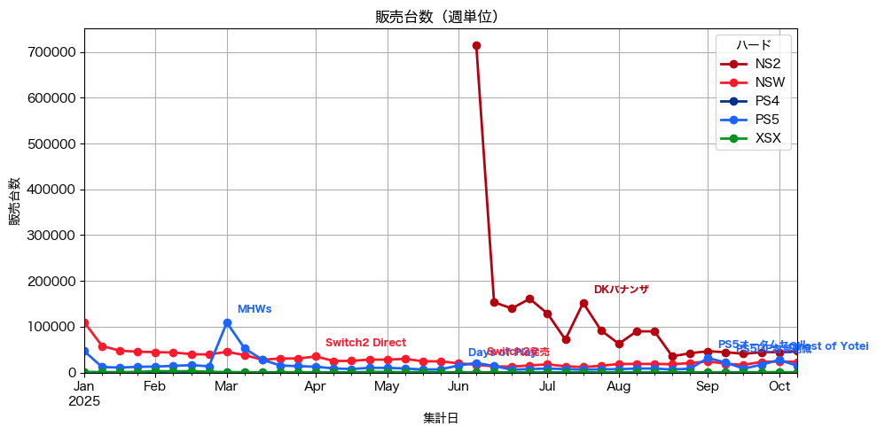

### 2025年の週販推移(拡大）

PS5はGhost of Yoteiの効果が切れて下に戻りつつありますが、次週にはAUTUMN SALEの効果が乗ってくるので2万台も期待できます。

Switchは極めて安定しています。来週はZAなのですが、Switch2が十分供給された場合には、次回は減る可能性もあります。

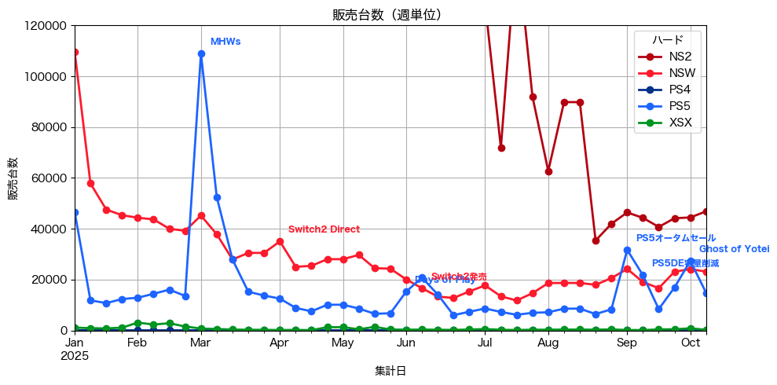

## 2025年月間販売推移

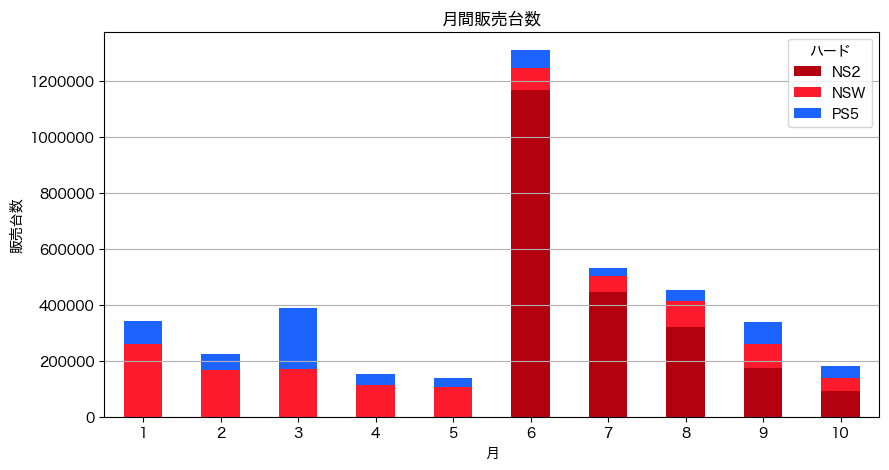

| hw month | NS2 | NSW | PS5 |
| --- | --- | --- | --- |
| 1 | 0 | 260,447 | 81,587 |
| 2 | 0 | 167,188 | 56,886 |
| 3 | 0 | 171,921 | 218,300 |
| 4 | 0 | 113,513 | 38,983 |
| 5 | 0 | 106,506 | 32,001 |
| 6 | 1,169,684 | 78,097 | 63,516 |
| 7 | 444,706 | 57,532 | 28,959 |
| 8 | 319,690 | 94,517 | 39,004 |
| 9 | 175,542 | 82,946 | 78,693 |
| 10 | 91,281 | 47,258 | 42,144 |

### Nintendo Switchの月間販売台数： 2023,2024年との比較

10月の前年比も9月に続いて低くなりそうな気配です。 ZAも出ますし、10月はSwitch2のデマンドが強いのでSwitchは控えめな値になると思われます。

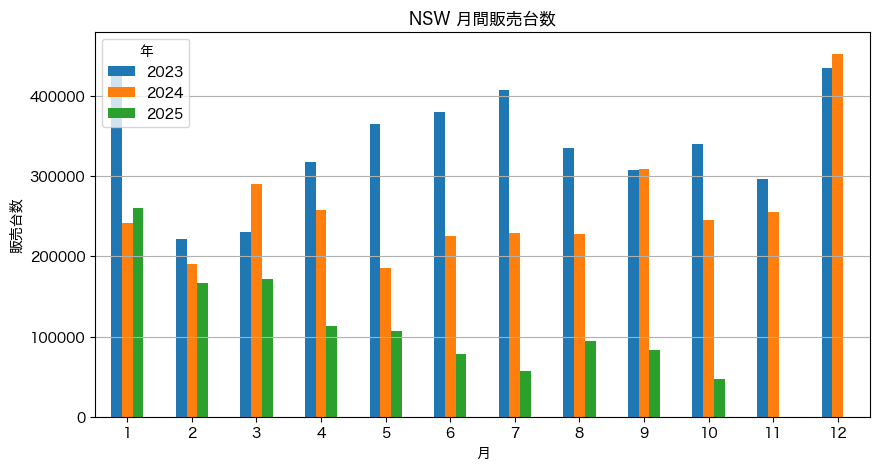

### PlayStation 5の月間販売台数： 2023, 2024年との比較

2025年10月のPS5は前年10月を超えるのは確実です。 4月から8月までは、大きく前年割れしていたPS5ですが、9月、10月と盛り返しつつあります。

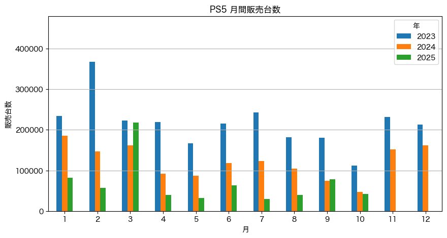

## 累計販売推移

累計については、Switch2の年末商戦で変化があるでしょう。

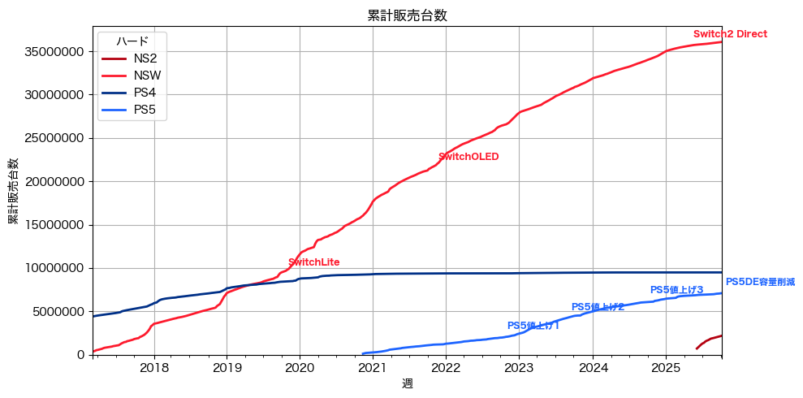

## Switch2販売状況

### 歴代機種との比較

ZA発売直前週です。予想通りSwitch2の推移はPS2に約2万台差まで接近しつつも上回っています。 Switch2は歴代2位の初動を維持しながらZAを迎えます。

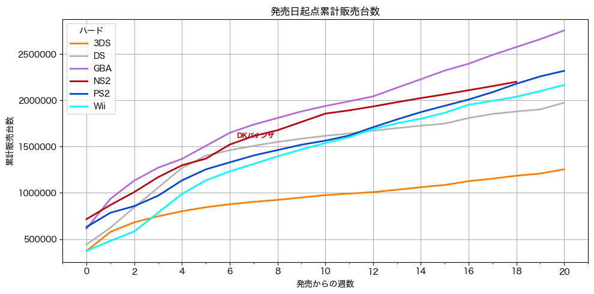

| ハード | 週数 | 販売数 |
| --- | --- | --- |
| GBA | 18 | 2,576,681 |
| NS2 | 18 | 2,200,903 |
| PS2 | 18 | 2,179,654 |
| Wii | 18 | 2,038,951 |
| DS | 18 | 1,879,864 |
| 3DS | 18 | 1,185,436 |

## Switch/Switch2ロンチ比較

#### 次週に注目のSwitch2出荷台数

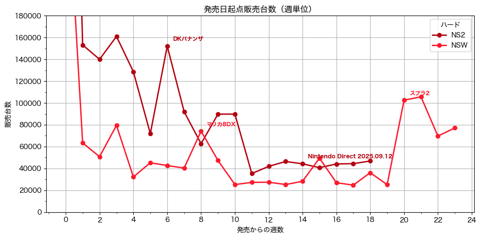

## 年単位の状況

全機種合わせた年毎のハード販売の状況です。 2025年は500万台を超える見込みですが、600万台到達は難しそうです。

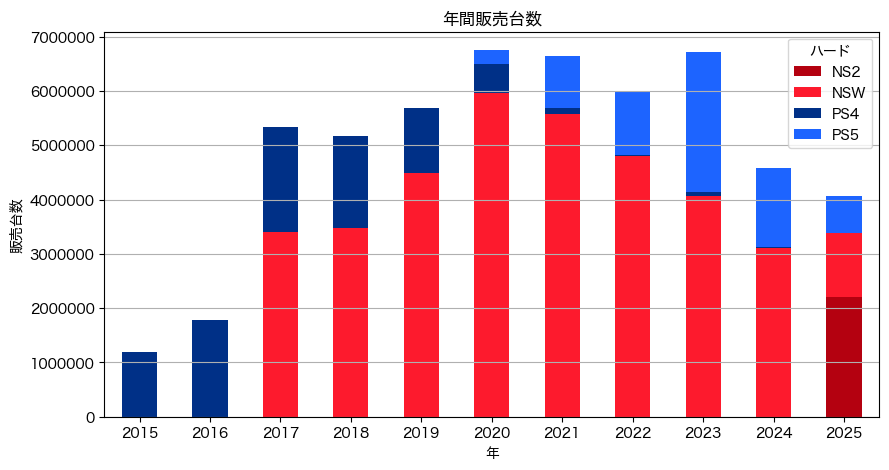